# Self-Driving Car Engineer Nanodegree

## Project: **Finding Lane Lines on the Road**

In the project below, I built a Python pipeline to identify lane lines in video streams. The end goal is to be able to extract and draw the line equations which describe the left and right lane lines. With these equations, a self-driving car would subsequently be able to determine if the vehicle is within or outside of its lane lines.

First we learn to detect and average lane lines through *images*, then we run our pipeline through a *video stream*.

- Analyze Images
  - Convert to Grayscale
  - Gaussian smoothing
  - Canny Edge Detection
  - Select Relevant Regions
  - Hough Transform line detection
- Analyze Videos

## Import Packages

```python
#importing some useful packages
import matplotlib.pyplot as plt
import matplotlib.image as mpimg
import numpy as np
import cv2
import math
import os
%matplotlib inline
```

## Helper Functions

Below are some helper functions used in my pipeline. I will go over them in more detail while processing a single image.

```python
def grayscale(img):
    """Applies the Grayscale transform
    This will return an image with only one color channel
    but NOTE: to see the returned image as grayscale
    (assuming your grayscaled image is called 'gray')
    you should call plt.imshow(gray, cmap='gray')"""
    return cv2.cvtColor(img, cv2.COLOR_RGB2GRAY)
    # Or use BGR2GRAY if you read an image with cv2.imread()
    # return cv2.cvtColor(img, cv2.COLOR_BGR2GRAY)

def canny(img, low_threshold, high_threshold):
    """Applies the Canny transform"""
    return cv2.Canny(img, low_threshold, high_threshold)

def gaussian_blur(img, kernel_size):
    """Applies a Gaussian Noise kernel"""
    return cv2.GaussianBlur(img, (kernel_size, kernel_size), 0)

def region_of_interest(img, vertices):
    """
    Applies an image mask.

    Only keeps the region of the image defined by the polygon
    formed from `vertices`. The rest of the image is set to black.
    """
    #defining a blank mask to start with
    mask = np.zeros_like(img)

    #defining a 3 channel or 1 channel color to fill the mask with depending on the input image
    if len(img.shape) > 2:
        channel_count = img.shape[2]  # i.e. 3 or 4 depending on your image
        ignore_mask_color = (255,) * channel_count
    else:
        ignore_mask_color = 255

    #filling pixels inside the polygon defined by "vertices" with the fill color
    cv2.fillPoly(mask, vertices, ignore_mask_color)

    #returning the image only where mask pixels are nonzero
    masked_image = cv2.bitwise_and(img, mask)
    return masked_image


def draw_lines(img, lines, color=[255, 0, 0], thickness=2):
    """
    Given the hough transformation array of line coordinates,
    identifies what the left and right lane equations are and draws them out.
    """
    # Initialize empty lists
    left_slope_list = []
    right_slope_list = []
    left_b_list = []
    right_b_list = []

    # Calculate slopes and categorize as left or right if != 0
    for index, line in enumerate(lines):
        for x1,y1,x2,y2 in line:
            # If x1=x2, then slope will be infinity--> Won't consider perfectly vertical lines in this project
            if (x1!=x2):
                temp_slope = (y1-y2)/(x1-x2)
                # Decreasing slope = most likely left lane
                if (temp_slope < 0 ):
                    left_slope_list.append(temp_slope)
                    left_b_list.append(y1-temp_slope*x1)
                # Append to right side
                elif (temp_slope>0):
                    right_slope_list.append(temp_slope)
                    right_b_list.append(y1-temp_slope*x1)

    ## Intercept Groupings Check ##
    # Part 1: ID Valid intercept Grouping #
    # Intuition:
    # If there are parallel left lane lines (consider a lane line, alongside a highway barrier shadow),
    # there should be noticable groupings in the intercept value.
    # The inner lane could be ID'd by a larger intercept, since it crosses x=0 at a larger y.
    # Otherwise, the function would take the average of the intercepts and slopes which could dramatically
    # skew the identified left lane line.
    temp_sorted_left_b = np.sort(left_b_list)

    # After sorting all intercepts, find the consecutive differences between each element
    # Intuition:
    # If the parallel lines are spaced apart, then if we take the average of them, we will result in a skewed lane line.
    # 100 is an aribrary value that currently suffices to ID parallel lines that are spaced apart
    # It would be good downstream to experiment with this value and tune it further based on more training sets.
    temp_sorted_left_b = np.split(temp_sorted_left_b, np.where(np.diff(temp_sorted_left_b) > 100)[0]+1)

    # Previous hough lane and canny parameters should have removed most outliers. This function assumes
    # that the groupings collected at this point represent actual lines that should be considered.
    # Since we want the larger lane lines, extract them here.
    if( len(temp_sorted_left_b)>1):

        # Part 2: Given ID'd intercept grouping, collect associated slope #
        # Find original indices for intercept elements so we can retrieve related slope
        indices = [i for i, j in enumerate(left_b_list) if j in temp_sorted_left_b[len(temp_sorted_left_b)-1]]
        left_slope_array = np.asarray(left_slope_list)[indices]
        left_b_array = np.asarray(left_b_list)[indices]
    else:
        # No groupings ID'd, take the original lists
        left_b_array = np.asarray(left_b_list)
        left_slope_array = np.asarray(left_slope_list)

    # Calculate median slope
    left_slope = np.median(left_slope_array)

    # Remove outliers
    i = 0
    while(i<len(left_slope_array)):

        # If slope is within +/- 20% of the median, should be ok
        # Might be better to tune this value to some constant rather than a relative value.
        # Since slopes can range from something like -0.3 (left lane) to 400 (right lane),
        # 20% is pretty arbitrary and inconsistent.
        # Nevertheless, I kept it here because it worked fairly well on the test videos
        if abs(abs(left_slope_array[i])-abs(left_slope)) > abs(left_slope)*.2:

            # Set slope to 0, will be discarded later
            left_slope_array = np.delete(left_slope_array, i)
            left_b_array = np.delete(left_b_array, i)
        else:
            #nothing deleted, increase increment
            i += 1

    # Calculate median intercept
    left_b = np.median(left_b_array)
    i = 0

    while(i < len(left_b_array)):
        # If intercept is within +/- 15 pixels of the median, should be ok
        # Using 15 px rather than a percentage of the original intercept to make the algorithm behave similarly
        # for large and small intercepts. This constant can be further tuned with additional training data.
        if abs(abs(left_b_array[i])-abs(left_b)) > 15:
            left_slope_array = np.delete(left_slope_array, i)
            left_b_array = np.delete(left_b_array, i)
        else:
            #nothing deleted, increase increment
            i +=1

    # recalculate average
    left_slope = np.mean(left_slope_array)
    left_b = np.mean(left_b_array)

    ### --------------------------------------------------------------------------------- ###
    ### Repeat above for the right side ###
    temp_sorted_right_b = np.sort(right_b_list)

    # Get groupings
    temp_sorted_right_b = np.split(temp_sorted_right_b, np.where(np.diff(temp_sorted_right_b) > 100)[0]+1)

    # Get the smaller groupings to find the right lane
    if( len(temp_sorted_right_b)>1):

        # Find original indices for intercept elements so we can retrieve related slope
        indices = [i for i, j in enumerate(right_b_list) if j in temp_sorted_right_b[0]]
        right_slope_array = np.asarray(right_slope_list)[indices]
        right_b_array = np.asarray(right_b_list)[indices]

    else:
        right_b_array = np.asarray(right_b_list)
        right_slope_array = np.asarray(right_slope_list)

    # Calculate median slope
    right_slope = np.median(right_slope_array)

    # Remove outliers
    i = 0
    while(i<len(right_slope_array)):

        if abs(abs(right_slope_array[i])-abs(right_slope)) > abs(right_slope)*.2:

            # Set slope to 0, will be discarded later
            right_slope_array = np.delete(right_slope_array, i)
            right_b_array = np.delete(right_b_array, i)

        else:
            #nothing deleted, increase increment
            i += 1


    # Calculate median intercept
    right_b = np.median(right_b_array)

    i = 0
    while(i < len(right_b_array)):
        if abs(abs(right_b_array[i])-abs(right_b)) > 15:

            right_slope_array = np.delete(right_slope_array, i)
            right_b_array = np.delete(right_b_array, i)
        else:
            #nothing deleted, increase increment
            i +=1

    # Get final average right slope/intercept
    right_slope = np.mean(right_slope_array)
    right_b = np.mean(right_b_array)

    # draw lines --> Extrapolates lane range within the masked region
    ysize = img.shape[1]
    lines_img = np.copy(img)*0

    if( not(math.isnan(left_b) or math.isnan(left_slope)) ):
        lines_img = cv2.line(lines_img, (int((ysize-left_b)/left_slope), ysize), (int(-left_b/left_slope),0), color=(255,0,0), thickness=5)
    if( not(math.isnan(right_b) or math.isnan(right_slope)) ):
        lines_img = cv2.line(lines_img, (int((ysize-right_b)/right_slope), ysize), (int(-right_b/right_slope),0), color=(255,0,0), thickness=5)

    return lines_img
def hough_lines(img, rho, theta, threshold, min_line_len, max_line_gap):
    """
    `img` should be the output of a Canny transform.

    Returns an image with hough lines drawn.
    """
    lines = cv2.HoughLinesP(img, rho, theta, threshold, np.array([]), min_line_len, max_line_gap)
    line_img = np.zeros((img.shape[0], img.shape[1], 3), dtype=np.uint8)
    line_img = draw_lines(line_img, lines)
    return line_img

# Python 3 has support for cool math symbols.

def weighted_img(img, initial_img, α=0.8, β=1., λ=0.):
    """
    `img` is the output of the hough_lines(), An image with lines drawn on it.
    Should be a blank image (all black) with lines drawn on it.

    `initial_img` should be the image before any processing.

    The result image is computed as follows:

    initial_img * α + img * β + λ
    NOTE: initial_img and img must be the same shape!
    """
    return cv2.addWeighted(initial_img, α, img, β, λ)
```

## Analyze Images

### A Single Image

First we will process an individual image to demonstrate how all the functions modify the inputted image. Next we will apply the same functions to all images in the test folder.

```
This image is: <class 'numpy.ndarray'> with dimensions: (540, 960, 3)
```

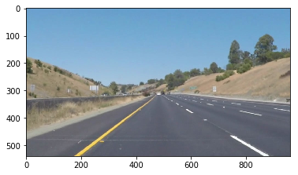

```python
# Reading in an image
image = mpimg.imread('test_images/whiteCarLaneSwitch.jpg')

#printing out some stats and plotting
print('This image is:', type(image), 'with dimensions:', image.shape)
plt.imshow(image)  # if you wanted to show a single color channel image called 'gray', for example, call as plt.imshow(gray, cmap='gray')
```

###### Step 1: Convert to grayscale

Since lane lines can appear in many colors and shades, we convert our image from an RGB image to a grayscale image. This simplifies the image so that we could more easily detect edges in the image which could be lane lines.

Further down, I noticed that converting the leftYellowSolid.mp4 video from its original color frame to grayscale was not sufficient to bring out the yellow edges. Consequently, I ended up splitting the RGB channels and only used the red and green values as input to the grayscale function. This seemed to make it easier for the pipeline to detect both yellow and white lane lines.

```
This image is: <class 'numpy.ndarray'> with dimensions: (540, 960)
```

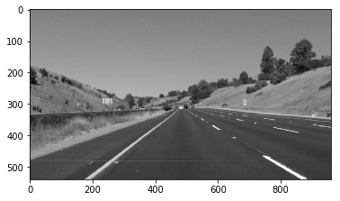

```python
# Convert the current image to grayscale & plot
gray = grayscale(image)
print('This image is:', type(image), 'with dimensions:', gray.shape)
plt.imshow(gray, cmap='gray')
```

###### Step 2: Apply Gaussian Filter

I used a larger kernel size (15) here to exagerate the effects of applying a Gaussian Filter. In the actual pipeline below, we use a kernel with size 7.

The Gaussian Filter kernel is a matrix which represents the Gaussian curve that is [convoluted](http://homepages.inf.ed.ac.uk/rbf/HIPR2/convolve.htm) over the image to remove noise. A larger kernel will smooth the image more, but also renders the image more fuzzy, and therefore the edges harder to detect-- and if detected, less accurate. Once this mask is applied, pixels in the image are blurred, such that small variances between pixels are muted, and larger differences are easier to capture.

```
This image is: <class 'numpy.ndarray'> with dimensions: (540, 960)
```

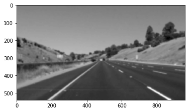

```python
# Define a kernel size for Gaussian smoothing / blurring
kernel_size =15# Must be an odd number (3, 5, 7...)
blur_gray = gaussian_blur(gray, kernel_size)
print('This image is:', type(image), 'with dimensions:', blur_gray.shape)
plt.imshow(blur_gray, cmap='gray')
```

###### Step 3: Detect Edges using Canny Edge Detection Algorithm

```
This image is: <class 'numpy.ndarray'> with dimensions: (540, 960)
```

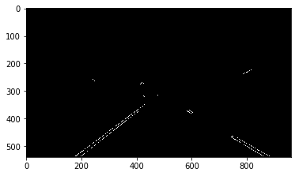

```python
low_threshold=100
high_threshold=140
edges=canny(blur_gray, low_threshold, high_threshold)
print('This image is:', type(image), 'with dimensions:', edges.shape)
plt.imshow(edges, cmap='gray')
```

###### Step 3: Extract Region of Interest

For this project, we are interested in the quadrilateral region in front of the car where a typical lane line will appear. We now black out all pixels outside the region directly in front the car camera, (which we assume is mounted at the center front of the car). This will help minimize other lines which may confuse our draw_lines function downstream and skew the detected lane lines.

```
This image is: <class 'numpy.ndarray'> with dimensions: (540, 960)
```

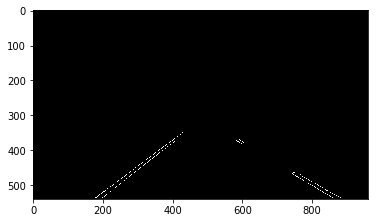

```python
# Define Vertices of the Region of Interest
ysize = image.shape[0]
xsize = image.shape[1]
# Explicitly set array datatypes to int 32, otherwise will default casut to 64 bit.
vertices = np.array([[[0,ysize],[xsize*2/5,ysize*3/5],[xsize*3/5,ysize*3/5],[xsize, ysize]]],dtype=np.int32)
region_select = region_of_interest(edges, vertices)
print('This image is:', type(image), 'with dimensions:', region_select.shape)
plt.imshow(region_select, cmap='gray')
```

###### Step 5: Extract Line parameters with Hough Transformation

While testing this pipeline, the parameters below seemed to find the lane lines most precisely. Nevertheless, these parameters could be further tuned with additional training data.

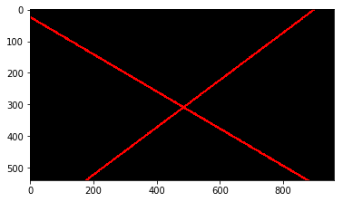

```python
# Get Lines with Hough
rho=1 # Distance resolution of Hough space grid-- keeping 1 as base unit
theta=np.pi/180 # Angular resolution of Hough space grid-- keeping as 1 deg base unit
threshold = 20 # Minimum number of intersections needed for a candidate line
min_line_len = 2
max_line_gap = 10
lines = hough_lines(region_select, rho, theta, threshold, min_line_len, max_line_gap)

plt.imshow(lines)
```

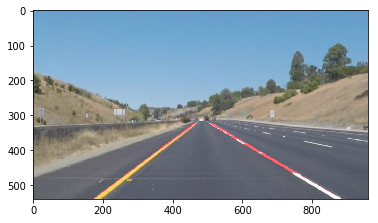

```python
# Get Final Image
lines = region_of_interest(lines,vertices)
final_image = weighted_img(image, lines)
plt.imshow(final_image)
```

### All Images

Here we test our solution on all test_images and make copies into the `test_images_output` directory.

```python
os.listdir("test_images/")
```

```
['solidWhiteCurve.jpg',
 'solidWhiteRight.jpg',
 'solidYellowCurve.jpg',
 'solidYellowCurve2.jpg',
 'solidYellowLeft.jpg',
 'whiteCarLaneSwitch.jpg']
```

```python
test_image_folder = "test_images/"
test_image_output_folder = "test_images_output/"

# Create output folder if it doesn't exist
if not os.path.exists(test_image_output_folder):
    os.makedirs(test_image_output_folder)

# Define a kernel size for Gaussian smoothing / blurring
kernel_size =7# Must be an odd number (3, 5, 7...)

low_threshold=100
high_threshold=140

ysize = image.shape[0]
xsize = image.shape[1]
# Explicitly set array datatypes to int 32, otherwise will default casut to 64 bit.
vertices = np.array([[[0,ysize],[xsize*2/5,ysize*3/5],[xsize*3/5,ysize*3/5],[xsize, ysize]]],dtype=np.int32)

# Hough Parameters
rho=1 # Distance resolution of Hough space grid-- keeping 1 as base unit
theta=np.pi/180 # Angular resolution of Hough space grid-- keeping as 1 deg base unit
threshold = 35 # Minimum number of intersections needed for a candidate line
min_line_len = 3
max_line_gap = 10

#Repeat above for all images:
for filename in os.listdir(test_image_folder):

    # Read in the image and convert to grayscale
    # Note: in the previous example we were reading a .jpg
    # Here we read a .png and convert to 0,255 bytescale
    image = mpimg.imread(os.path.join(test_image_folder,filename))

    # Convert the current image to grayscale
    gray = grayscale(image)

    blur_gray = gaussian_blur(gray, kernel_size)

    edges = canny(blur_gray, low_threshold, high_threshold)

    region_select = region_of_interest(edges, vertices)

    lines = hough_lines(region_select, rho, theta, threshold, min_line_len, max_line_gap)
    lines = region_of_interest(lines,vertices)
    final_image = weighted_img(image, lines)

    # Uncomment the following code if you are running the code locally and wish to save the image
    mpimg.imsave(os.path.join(test_image_output_folder,"%s" %(filename)), final_image)
```

## Test on Videos

Now we will run the pipeline through three videos:

- solidWhiteRight.mp4
- solidYellowLeft.mp4
- challenge.mp4

```python
# Install imagio to use moviepy
import imageio
imageio.plugins.ffmpeg.download()
```

```python
# Import everything needed to edit/save/watch video clips
from moviepy.editor import VideoFileClip
from IPython.display import HTML
```

```python
def process_image(image):
    # NOTE: The output you return should be a color image (3 channel) for processing video below

    # Define a kernel size for Gaussian smoothing / blurring
    kernel_size =7# Must be an odd number (3, 5, 7...)

    low_threshold=100
    high_threshold=140

    ysize = image.shape[0]
    xsize = image.shape[1]
    # Explicitly set array datatypes to int 32, otherwise will default casut to 64 bit.
    # Use this vertices definition if running the challenge video. We modified it here since the camera was mounted
    # differently, resulting in the edges of the hood to be detectable.
    # By using the vertices definition below, we ignore the edges of the hood.
    # vertices = np.array([[[0,650],[xsize*2/5,ysize*3/5],[xsize*3/5,ysize*3/5],[xsize, 650]]],dtype=np.int32)
    # Normal: Use this definition for the solidYellowLeft and SolidWhiteRight videos, since the hood is not visible
    vertices = np.array([[[0,ysize],[xsize*2/5,ysize*3/5],[xsize*3/5,ysize*3/5],[xsize, ysize]]],dtype=np.int32)

    # Hough Parameters
    rho=1 # Distance resolution of Hough space grid-- keeping 1 as base unit
    theta=np.pi/180 # Angular resolution of Hough space grid-- keeping as 1 deg base unit
    # Chose 35 because it seems to catch longer lines and not little dashes which might through off the slope estimate
    threshold = 35 # Minimum number of intersections needed for a candidate line
    min_line_len = 30
    max_line_gap = 25

    # Get Color Channels
    r,g,b= cv2.split(image)

    # Convert the current image to grayscale
    # This combination of RGB values brought out the yellow and white lines simulatesouly the best given my informal trials
    gray = grayscale(np.dstack([g,r,r]))
    # gray = grayscale(image)
    # print('Grayscale', type(image), 'with dimensions:', gray.shape)

    blur_gray = gaussian_blur(gray, kernel_size)
    # print('Gaussian_blr', type(image), 'with dimensions:', blur_gray.shape)

    edges = canny(blur_gray, low_threshold, high_threshold)
    # print('Canny', type(image), 'with dimensions:', edges.shape)

    region_select = region_of_interest(edges, vertices)
    # print('Region Of INterest', type(image), 'with dimensions:', region_select.shape)

    lines = hough_lines(region_select, rho, theta, threshold, min_line_len, max_line_gap)
    # print('Hough', type(image), 'with dimensions:', lines.shape)


    lines = region_of_interest(lines,vertices)

    result = weighted_img(image, lines)
    # print('Weighted', type(image), 'with dimensions:', result.shape)

    return result
```

Let's try the one with the the videos ...

```python
# Define a kernel size for Gaussian smoothing / blurring
kernel_size =7# Must be an odd number (3, 5, 7...)

low_threshold=100
high_threshold=140


# Hough Parameters
rho=1 # Distance resolution of Hough space grid-- keeping 1 as base unit
theta=np.pi/180 # Angular resolution of Hough space grid-- keeping as 1 deg base unit
threshold = 35 # Minimum number of intersections needed for a candidate line
min_line_len = 30
max_line_gap = 25
```

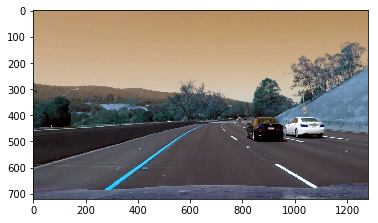

```python
cap = cv2.VideoCapture("test_videos/challenge.mp4")
cap.set(1,24)
ret, frame = cap.read()
b,g,r= cv2.split(frame)


plt.imshow(frame)
#frame.shape
```

```
Grayscale <class 'numpy.ndarray'> with dimensions: (720, 1280)
```

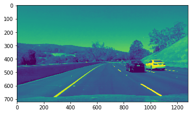

```python
ysize = frame.shape[0]
xsize = frame.shape[1]
# Explicitly set array datatypes to int 32, otherwise will default casut to 64 bit.
# bottom left set at 200 since all frames seem to capture the edge of the lane there. Assuming standard lane size.
#vertices = np.array([[[0,ysize],[xsize*2/5,ysize*3/5],[xsize*3/5,ysize*3/5],[xsize, ysize]]],dtype=np.int32)
vertices = np.array([[[0,650],[xsize*2/5,ysize*3/5],[xsize*3/5,ysize*3/5],[xsize, 650]]],dtype=np.int32)

# Convert the current image to grayscale
gray = grayscale(np.dstack([g,r,r]))
#gray = grayscale(frame)

print('Grayscale', type(b), 'with dimensions:', b.shape)
plt.imshow(gray)
```

```
Gaussian_blr <class 'numpy.ndarray'> with dimensions: (720, 1280)
```

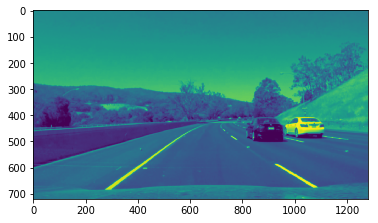

```python
blur_gray = gaussian_blur(gray, kernel_size)
print('Gaussian_blr', type(blur_gray), 'with dimensions:', blur_gray.shape)
plt.imshow(blur_gray)
```

```
Canny <class 'numpy.ndarray'> with dimensions: (720, 1280)
```

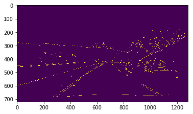

```python
edges = canny(blur_gray, low_threshold, high_threshold)
print('Canny', type(edges), 'with dimensions:', edges.shape)
plt.imshow(edges)
```

```
Region Of INterest <class 'numpy.ndarray'> with dimensions: (720, 1280)
```

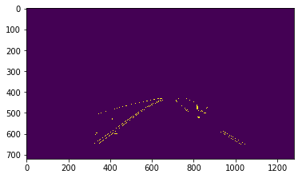

```python
region_select = region_of_interest(edges, vertices)
print('Region Of INterest', type(region_select), 'with dimensions:', region_select.shape)
plt.imshow(region_select)
```

```
Hough <class 'numpy.ndarray'> with dimensions: (720, 1280, 3)
```

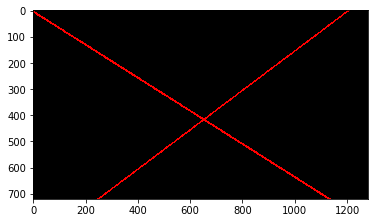

```python
lines = hough_lines(region_select, rho, theta, threshold, min_line_len, max_line_gap)
print('Hough', type(lines), 'with dimensions:', lines.shape)
plt.imshow(lines)
```

```
Weighted <class 'numpy.ndarray'> with dimensions: (720, 1280, 3)
```

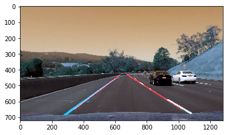

```python
lines = region_of_interest(lines,vertices)
result = weighted_img(frame, lines)
print('Weighted', type(result), 'with dimensions:', result.shape)
plt.imshow(result)
```

### Solid White Right

```python
# Create video Output folder
test_video_output_folder = "test_videos_output/"

# Create output folder if it doesn't exist
if not os.path.exists(test_video_output_folder):
    os.makedirs(test_video_output_folder)
white_output = "%ssolidWhiteRight.mp4" %(test_video_output_folder)


## To speed up the testing process you may want to try your pipeline on a shorter subclip of the video
## To do so add .subclip(start_second,end_second) to the end of the line below
## Where start_second and end_second are integer values representing the start and end of the subclip
## You may also uncomment the following line for a subclip of the first 5 seconds
#clip1 = VideoFileClip("test_videos/solidWhiteRight.mp4").subclip(0,5)
clip1 = VideoFileClip("test_videos/solidWhiteRight.mp4")
white_clip = clip1.fl_image(process_image) #NOTE: this function expects color images!!
#%time
white_clip.write_videofile(white_output, audio=False)
```

```
[MoviePy] >>>> Building video test_videos_output/solidWhiteRight.mp4
[MoviePy] Writing video test_videos_output/solidWhiteRight.mp4
```

```
[MoviePy] Done.
[MoviePy] >>>> Video ready: test_videos_output/solidWhiteRight.mp4
```

Play the video inline, or if you prefer find the video in your filesystem (should be in the same directory) and play it in your video player of choice.

```python
HTML("""
<video width="960" height="540" controls>
  <source src="{0}">
</video>
""".format(white_output))
```

[video not shown]

### Solid Yellow Left

```python
yellow_output = 'test_videos_output/solidYellowLeft.mp4'
## To speed up the testing process you may want to try your pipeline on a shorter subclip of the video
## To do so add .subclip(start_second,end_second) to the end of the line below
## Where start_second and end_second are integer values representing the start and end of the subclip
## You may also uncomment the following line for a subclip of the first 5 seconds
##clip2 = VideoFileClip('test_videos/solidYellowLeft.mp4').subclip(0,5)
clip2 = VideoFileClip('test_videos/solidYellowLeft.mp4')
yellow_clip = clip2.fl_image(process_image)
%time yellow_clip.write_videofile(yellow_output, audio=False)
```

```
[MoviePy] >>>> Building video test_videos_output/solidYellowLeft.mp4
[MoviePy] Writing video test_videos_output/solidYellowLeft.mp4
```

```
[MoviePy] Done.
[MoviePy] >>>> Video ready: test_videos_output/solidYellowLeft.mp4

Wall time: 15.3 s
```

```python
HTML("""
<video width="960" height="540" controls>
  <source src="{0}">
</video>
""".format(yellow_output))
```

[video not shown]

### Challenge

```python
# need to change this video's mask because camera is mounted differently, adding new confusing horizontal edges
# vertices = np.array([[[0,650],[xsize*2/5,ysize*3/5],[xsize*3/5,ysize*3/5],[xsize, 650]]],dtype=np.int32)

challenge_output = 'test_videos_output/challenge.mp4'

## To speed up the testing process you may want to try your pipeline on a shorter subclip of the video
## To do so add .subclip(start_second,end_second) to the end of the line below
## Where start_second and end_second are integer values representing the start and end of the subclip
## You may also uncomment the following line for a subclip of the first 5 seconds
##clip3 = VideoFileClip('test_videos/challenge.mp4').subclip(0,5)
clip3 = VideoFileClip('test_videos/challenge.mp4')
challenge_clip = clip3.fl_image(process_image)
%time challenge_clip.write_videofile(challenge_output, audio=False)
```

```
[MoviePy] >>>> Building video test_videos_output/challenge.mp4
[MoviePy] Writing video test_videos_output/challenge.mp4
```

```
[MoviePy] Done.
[MoviePy] >>>> Video ready: test_videos_output/challenge.mp4

Wall time: 11.2 s
```

```python
HTML("""
<video width="960" height="540" controls>
  <source src="{0}">
</video>
""".format(challenge_output))
```

[video not shown]